# R Notebook

loading the dataset

```r
install.packages("readxl")
library(readxl)
# Replace "path/to/your/file.xlsx" with the actual file path
data <- read_excel("~/Downloads/mudkip_ftw.xlsx", sheet = "Sheet1")
head(data)
```

| participant | playtime_hours | satisfaction_rating | group |
| --- | --- | --- | --- |
| P1 | 164.79079 | 3 | treecko |
| P2 | 52.51891 | 3 | treecko |
| P3 | 72.16690 | 3 | treecko |
| P4 | 85.00883 | 5 | treecko |
| P5 | 125.26391 | 6 | treecko |
| P6 | 76.94546 | 3 | treecko |

```r
colnames(data)
```

```
[1] "participant"         "playtime_hours"      "satisfaction_rating" "group"
```

```r
install.packages("ggplot2")
library(ggplot2)
```

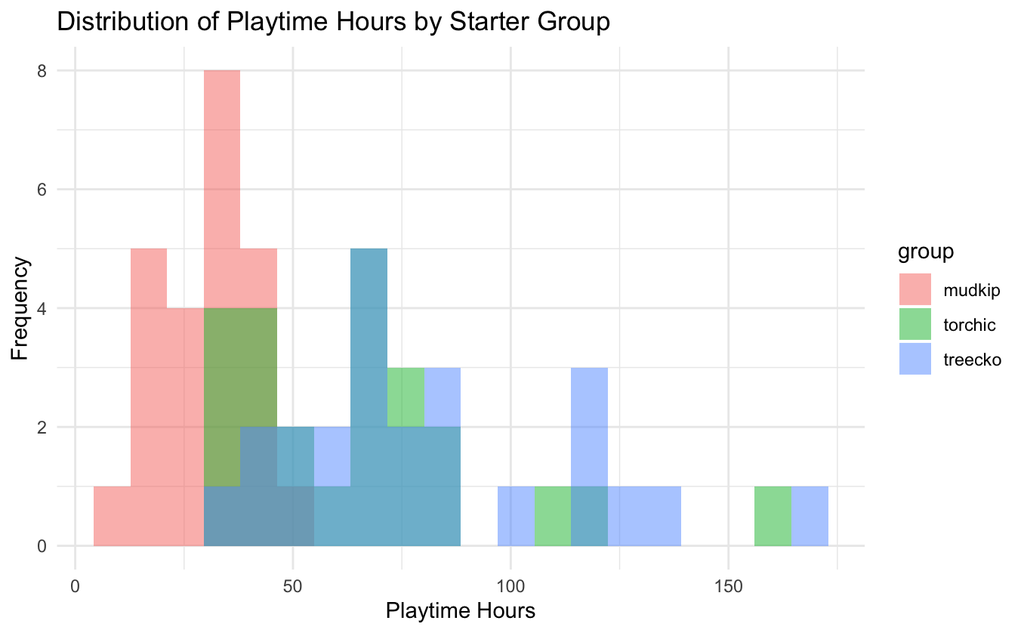

```r
ggplot(data, aes(x = playtime_hours, fill = group)) +
  geom_histogram(alpha = 0.5, position = "identity", bins = 20) +
  theme_minimal() +
  labs(title = "Distribution of Playtime Hours by Starter Group", x = "Playtime Hours", y = "Frequency")
```

```r
NA
NA
```

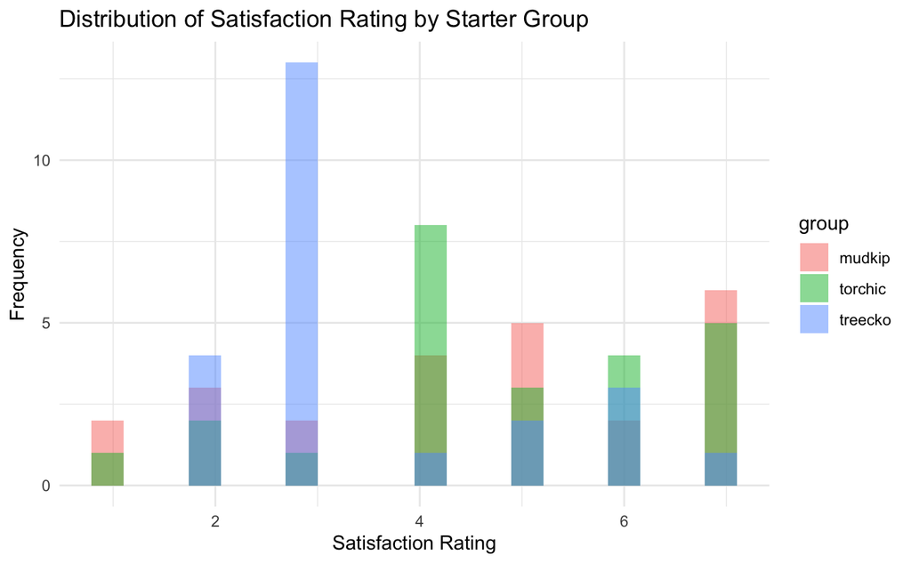

```r
# Histogram for satisfaction_rating by group
ggplot(data, aes(x = satisfaction_rating, fill = group)) +
  geom_histogram(alpha = 0.5, position = "identity", bins = 20) +
  theme_minimal() +
  labs(title = "Distribution of Satisfaction Rating by Starter Group", x = "Satisfaction Rating", y = "Frequency")
```

shpiro-wilk test to be sure its normal (has to be on numeric data)

```r
# shapir-Wilk test for group A
# Shapiro-Wilk test for playtime_hours
shapiro_playtime <- shapiro.test(data$playtime_hours)
print(shapiro_playtime)
```

```
    Shapiro-Wilk normality test

data:  data$playtime_hours
W = 0.90722, p-value = 6.028e-05
```

```r
# Shapiro-Wilk test for satisfaction_rating
shapiro_satisfaction <- shapiro.test(data$satisfaction_rating)
print(shapiro_satisfaction)
```

```
    Shapiro-Wilk normality test

data:  data$satisfaction_rating
W = 0.92663, p-value = 0.0004284
```

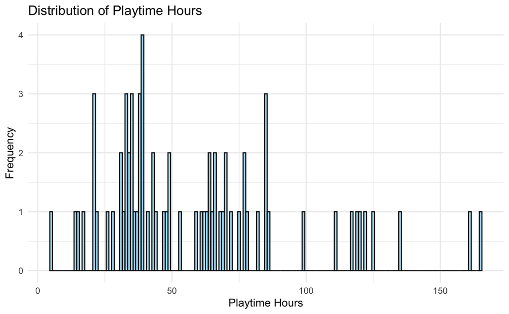

```r
# Load the necessary library
library(ggplot2)

# Histogram for Playtime Hours
ggplot(data, aes(x = playtime_hours)) +
  geom_histogram(binwidth = 1, fill = "skyblue", color = "black", alpha = 0.7) +
  labs(title = "Distribution of Playtime Hours", x = "Playtime Hours", y = "Frequency") +
  theme_minimal()
```

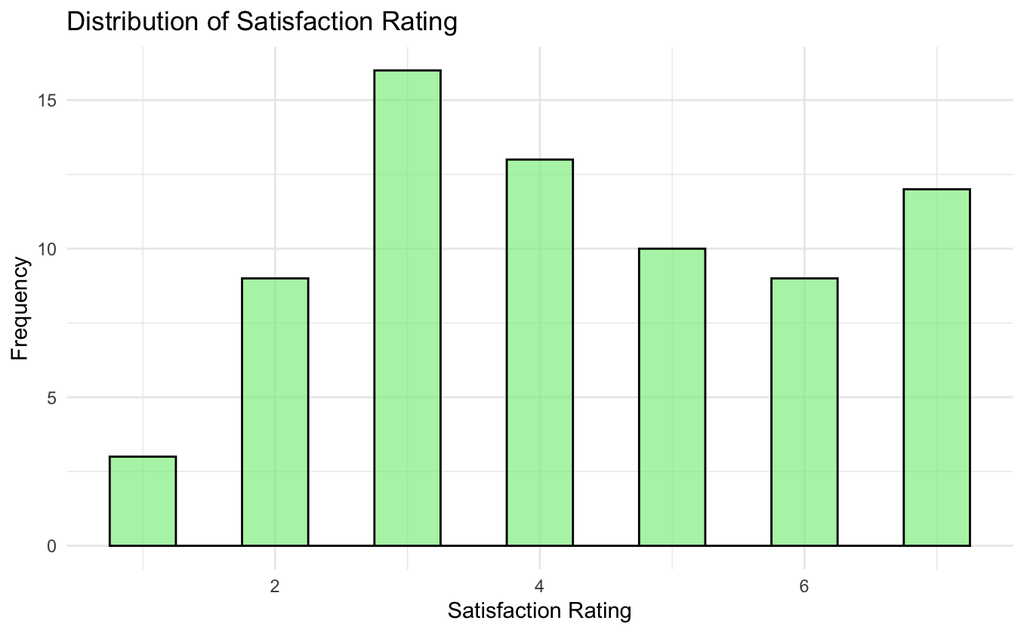

```r
# Histogram for Satisfaction Rating
ggplot(data, aes(x = satisfaction_rating)) +
  geom_histogram(binwidth = 0.5, fill = "lightgreen", color = "black", alpha = 0.7) +
  labs(title = "Distribution of Satisfaction Rating", x = "Satisfaction Rating", y = "Frequency") +
  theme_minimal()
```

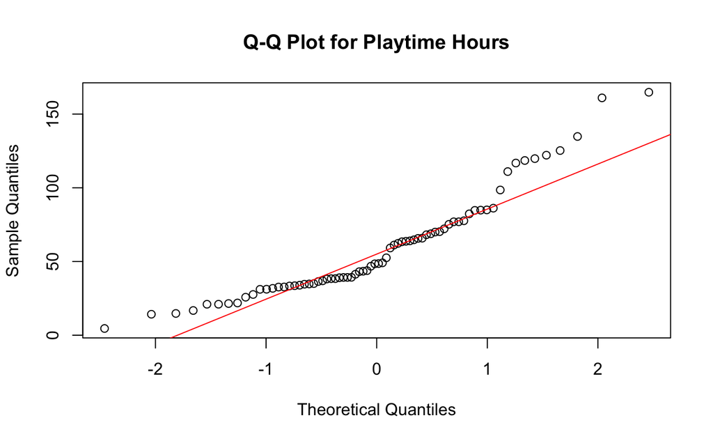

```r
# Q-Q plot for Playtime Hours
qqnorm(data$playtime_hours, main = "Q-Q Plot for Playtime Hours")
qqline(data$playtime_hours, col = "red")
```

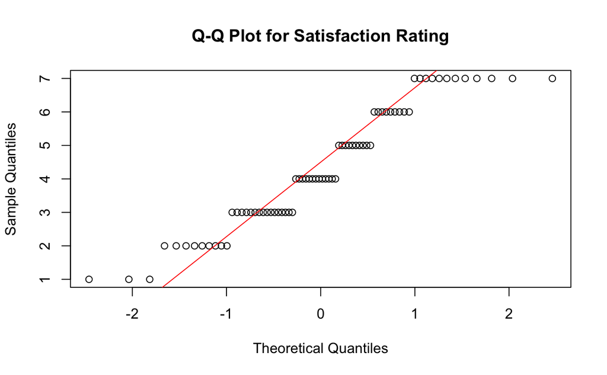

```r
# Q-Q plot for Satisfaction Rating
qqnorm(data$satisfaction_rating, main = "Q-Q Plot for Satisfaction Rating")
qqline(data$satisfaction_rating, col = "red")
```

its significant so its not normal, running **non-parametric tests** that do not rely on the assumption of normality.

```r
# Kruskal-Wallis test for playtime_hours across groups
kruskal_playtime <- kruskal.test(playtime_hours ~ group, data = data)
print(kruskal_playtime)
```

```
    Kruskal-Wallis rank sum test

data:  playtime_hours by group
Kruskal-Wallis chi-squared = 39.626, df = 2, p-value = 2.485e-09
```

```r
# Kruskal-Wallis test for satisfaction_rating across groups
kruskal_satisfaction <- kruskal.test(satisfaction_rating ~ group, data = data)
print(kruskal_satisfaction)
```

```
    Kruskal-Wallis rank sum test

data:  satisfaction_rating by group
Kruskal-Wallis chi-squared = 6.9739, df = 2, p-value = 0.03059
```

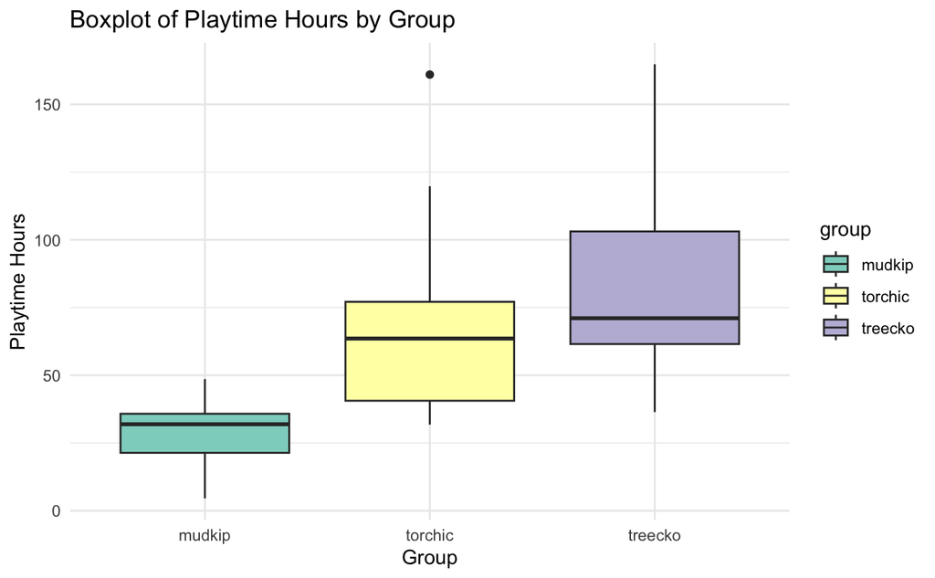

```r
# Boxplot for Playtime Hours across groups
ggplot(data, aes(x = group, y = playtime_hours, fill = group)) +
  geom_boxplot() +
  labs(title = "Boxplot of Playtime Hours by Group", x = "Group", y = "Playtime Hours") +
  theme_minimal() +
  scale_fill_brewer(palette = "Set3") # You can change the color palette if desired
```

[figure not shown]

```r
# Boxplot for Satisfaction Rating across groups
ggplot(data, aes(x = group, y = satisfaction_rating, fill = group)) +
  geom_boxplot() +
  labs(title = "Boxplot of Satisfaction Rating by Group", x = "Group", y = "Satisfaction Rating") +
  theme_minimal() +
  scale_fill_brewer(palette = "Set3") # Again, customize color palette if preferred
```

The null hypothesis for the test is that the distribution of the variable is the same across all groups. If the p-value is less than 0.05, you can reject the null hypothesis, indicating a significant difference between the groups.

```r
# Install the 'dunn.test' package for the post-hoc pairwise Wilcoxon test
install.packages("dunn.test")
```

```
Error in install.packages : Updating loaded packages
```

```r
library(dunn.test)
```

```r
library(dunn.test)
# Perform Dunn's Test for playtime_hours across groups
dunn_playtime <- dunn.test(data$playtime_hours, data$group, kw = TRUE, label = TRUE, list = TRUE)
```

```
  Kruskal-Wallis rank sum test

data: x and group
Kruskal-Wallis chi-squared = 39.6258, df = 2, p-value = 0

                           Comparison of x by group
                                (No adjustment)
Col Mean-|
Row Mean |     mudkip    torchic
---------+----------------------
 torchic |  -4.517348
         |    0.0000*
 treecko |  -6.055316  -1.537967
         |    0.0000*     0.0620


List of pairwise comparisons: Z statistic (p-value)
---------------------------------------
mudkip - torchic  : -4.517348 (0.0000)*
mudkip - treecko  : -6.055316 (0.0000)*
torchic - treecko : -1.537967 (0.0620)

alpha = 0.05
Reject Ho if p <= alpha/2
```

```r
print(dunn_playtime)
```

```
$chi2
[1] 39.62576

$Z
[1] -4.517349 -6.055316 -1.537968

$P
[1] 3.130935e-06 7.007096e-10 6.202827e-02

$P.adjusted
[1] 3.130935e-06 7.007096e-10 6.202827e-02

$comparisons
[1] "mudkip - torchic"  "mudkip - treecko"  "torchic - treecko"
```

```r
# Perform Dunn's Test for satisfaction_rating across groups
dunn_satisfaction <- dunn.test(data$satisfaction_rating, data$group, kw = TRUE, label = TRUE, list = TRUE)
```

```
  Kruskal-Wallis rank sum test

data: x and group
Kruskal-Wallis chi-squared = 6.9739, df = 2, p-value = 0.03

                           Comparison of x by group
                                (No adjustment)
Col Mean-|
Row Mean |     mudkip    torchic
---------+----------------------
 torchic |  -0.433702
         |     0.3323
 treecko |   2.039101   2.472803
         |    0.0207*    0.0067*


List of pairwise comparisons: Z statistic (p-value)
---------------------------------------
mudkip - torchic  : -0.433702 (0.3323)
mudkip - treecko  :  2.039101 (0.0207)*
torchic - treecko :  2.472803 (0.0067)*

alpha = 0.05
Reject Ho if p <= alpha/2
```

```r
print(dunn_satisfaction)
```

```
$chi2
[1] 6.973861

$Z
[1] -0.4337025  2.0391014  2.4728039

$P
[1] 0.332252238 0.020719956 0.006702884

$P.adjusted
[1] 0.332252238 0.020719956 0.006702884

$comparisons
[1] "mudkip - torchic"  "mudkip - treecko"  "torchic - treecko"
```

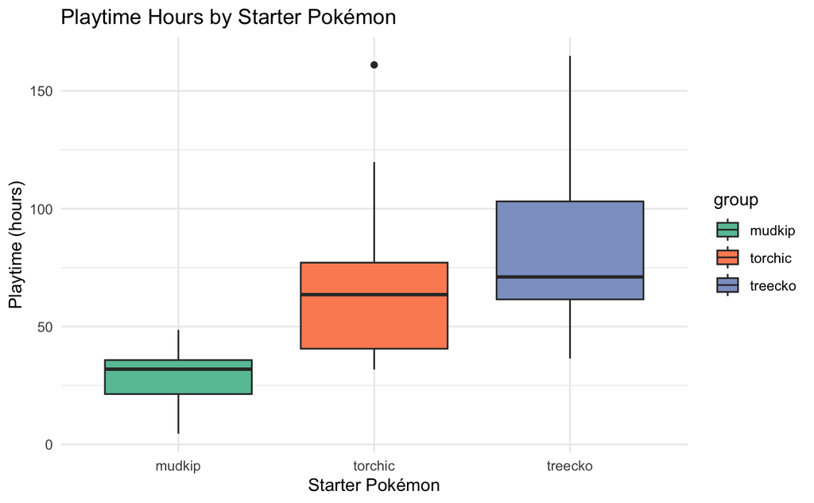

```r
# Load necessary library
library(ggplot2)

# Boxplot for Playtime Hours by Group
ggplot(data, aes(x = group, y = playtime_hours, fill = group)) +
  geom_boxplot() +
  theme_minimal() +
  labs(title = "Playtime Hours by Starter Pokémon",
       x = "Starter Pokémon",
       y = "Playtime (hours)") +
  scale_fill_brewer(palette = "Set2")
```

```r
NA
NA
```

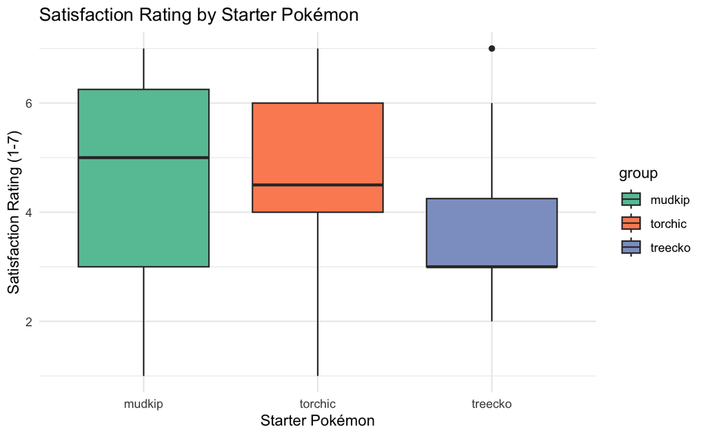

```r
# Boxplot for Satisfaction Rating by Group
ggplot(data, aes(x = group, y = satisfaction_rating, fill = group)) +
  geom_boxplot() +
  theme_minimal() +
  labs(title = "Satisfaction Rating by Starter Pokémon",
       x = "Starter Pokémon",
       y = "Satisfaction Rating (1-7)") +
  scale_fill_brewer(palette = "Set2")
```

- **For Playtime Hours**:

  There are significant differences between the groups **Mudkip**, **Torchic**, and **Treecko** for **playtime hours**. Specifically, **Mudkip** is significantly different from both **Torchic** and **Treecko** in terms of playtime, while there is no significant difference between **Torchic** and **Treecko**.

  **For Satisfaction Rating**:

  There are significant differences in **satisfaction ratings** between **Mudkip** and **Treecko**, as well as **Torchic** and **Treecko**. However, **Mudkip** and **Torchic** do not show a significant difference in satisfaction ratings.